# Exploration of Mountain Yellow-legged Frog (Rana muscosa) Counts in Southern Sierra Nevada Waterbodies

Renee LaManna

1/14/2022

## Setup

```r
knitr::opts_chunk$set(echo = TRUE, message=FALSE, warning=FALSE)

# Attach necessary pkgs and set code chunk options
library(tidyverse)
library(janitor)
library(here)
library(lubridate)
library(ggplot2)
library(patchwork)
```

## Read in the data

```r
# Read in the data `sierra_amphibians.csv` as `amphibians` using read_csv() and here() pkgs
amphibians <- read_csv(here("data", "sierra_amphibians.csv"))
```

## Initial data wrangling

- Create new df, `ramu_amp` from `amphibians`
- Filter to only include the species `RAMU`
- Convert `survey_date` to class date using lubridate pkg and then create a column with just the year
- Filter to only include: `SubAdult`, `Tadpole`, and `Adult` lifestages
- Select only necessary columns and rename as needed

```r
ramu_amp <- amphibians %>%
  filter(amphibian_species == "RAMU") %>%
  mutate(date = mdy(survey_date)) %>%
  mutate(year = year(date)) %>%
  filter(amphibian_life_stage %in% c("SubAdult", "Tadpole", "Adult")) %>%
  select("amphibian_species", "lake_id", "year", "amphibian_life_stage") %>%
  rename(life_stage = amphibian_life_stage)
```

## Data wrangling: 1st figure

- Create a new df, ramu_amp_1 that will be used for for the 1st figure
- Group by year and life stage, then summarise to get counts

```r
ramu_amp_1 <- ramu_amp %>%
  group_by(year, life_stage) %>%
  summarise(count=n())
```

## Data visualization: 1st figure

- Use ggplot to create a column graph and store as `p1` to make finalized compound graph later
- Adjust aesthetics as needed, use labs() to rename axis, set x-acis using scale_x_continuous()

```r
p1 <- ggplot(data = ramu_amp_1, aes(x = year, y = count)) +
  geom_col(aes(fill = life_stage)) +
  theme_minimal() +
  theme(legend.background = element_rect(fill = "grey92", color = "snow2")) +
  scale_fill_manual(values = c("palegoldenrod", "palegreen4", "lightskyblue2")) +
  labs(x = "Year", y = "Count", fill = "Life Stage")  +
  scale_x_continuous(breaks = c(1995, 1996, 1997, 2000, 2001, 2002))
```

## Data wrangling: 2nd figure

- Create a new df, `ramu_amp_2` for 2nd figure
- Filter to only include Adult and Subadult life stages
- Group by lake_id & summarise by count, then use slice_max() and order_by() to get the top 8 lakes w/ highest count
- Rename lake_id, so they look more like a name, rather than a numerical value & then order them by descending order

```r
ramu_amp_2 <- ramu_amp %>%
  filter(life_stage %in% c("Adult", "SubAdult")) %>%
  group_by(lake_id) %>%
  summarise(count = n()) %>%
  slice_max(order_by = count, n=8) %>%
  mutate(lake_id = case_when(
   lake_id == "50183" ~ "#50183",
   lake_id == "70583" ~ "#70583",
   lake_id == "10226" ~ "#10226",
   lake_id == "41322" ~ "#41322",
   lake_id == "50219" ~ "#50219",
   lake_id == "10101" ~ "#10101",
   lake_id == "11192" ~ "#11192",
   lake_id == "11332" ~ "#11332"
  )) %>%
  mutate(lake_id = fct_reorder(lake_id, desc(count)))
```

## Data visualization: 2nd figure

- Use ggplot to create a column graph and store as `p2` to use later in finalized compound graph
- Adjust aesthetics and use labs() to rename axis

```r
p2 <- ggplot(data = ramu_amp_2, aes(x=count, y=lake_id)) +
  geom_col(fill = "aquamarine4", alpha = 0.8 ) +
  theme_minimal() +
  labs(x = "Count", y = "Lake Identification")
```

## Finalized compound figure

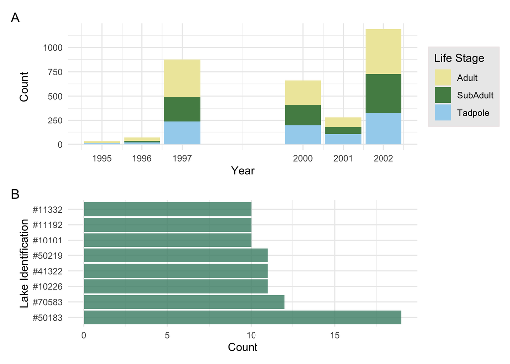

```r
(p1 / p2) +
  plot_annotation(tag_levels = c('A'))
```

**Figure 1.** Total mountain yellow-legged frog (*Rana muscosa*) count each year across all water bodies in the southern Sierra Nevada categorized by life stages: Adult, SubAdult, and Tadpole displayed in **A.**. Top 8 lakes in southern Sierra Nevada with the highest counts of Adult and SubAdult mountain yellow-legged frog (*Rana muscosa*) displayed in **B.** Knapp et al. (2020).

**Data citation:** Knapp, R.A., C. Pavelka, E.E. Hegeman, and T.C. Smith. 2020. The Sierra Lakes Inventory Project: Non-Native fish and community composition of lakes and ponds in the Sierra Nevada, California ver 2. Environmental Data Initiative. https://doi.org/10.6073/pasta/d835832d7fd00d9e4466e44eea87fab3